# Final Project

Matthew Bentham and John Murrowood

2023-04-30

# Energy Demand Victoria

##### MATH1318: Final Project

Matthew Bentham 3923076 John Murrowood 3923075

# 1. Introduction

**Research Question**: What are the most accurate forecasts for monthly averaged total daily electricity demand in Victoria for the next 10 months?

With the resurrection of the SEC , announcement of offshore wind farms in south east Victoria and Victoria’s renewable energy target of 50% by 2030, being able to accurately predict energy demand on a continual basis is becoming more and more important. As renewable energy sources like wind and solar do not produce constant energy outputs, accurate forecasting of energy demand throughout the day is essential to ensure renewable energy sources are utilized efficiently. Although demand forecasting is increasingly relevant when incorporating renewable into the grid, demand forecasting in general reduces over and underproduction of energy and minimizes energy waste as a whole.

**Data Source:**https://www.kaggle.com/datasets/aramacus/electricity-demand-in-victoria-australia

- **date** : datetime, the date of the recording
- **demand** : float, a total daily electricity demand in MWh
- **RRP** : float, a recommended retail price in AUD$ / MWh
- **demand_pos_RRP** : float, a total daily demand at positive RRP in MWh
- **RRP_positive** : float, an averaged positive RRP, weighted by the corresponding intraday demand in AUD$ / MWh
- **demand_neg_RRP** : float, an total daily demand at negative RRP in MWh
- **RRP_negative** : float, an average negative RRP, weighted by the corresponding intraday demand in AUD$ / MWh
- **frac_at_neg_RRP** : float, a fraction of the day when the demand was traded at negative RRP
- **min_temperature** : float, minimum temperature during the day in Celsius
- **max_temperature** : float, maximum temperature during the day in Celsius
- **solar_exposure** : float, total daily sunlight energy in MJ/m^2
- **rainfall** : float, daily rainfall in mm
- **school_day** : boolean, if students were at school on that day
- **holiday** : boolean, if the day was a state or national holiday

*Note* : All code provided is written in Rstudio using R 4.2.0

# 1.1 Functions used

```r
sort.score <- function(x, score = c("bic", "aic")){
if (score == "aic"){
x[with(x, order(AIC)),]
} else if (score == "bic") {
x[with(x, order(BIC)),]
} else {
warning('score = "x" only accepts valid arguments ("aic","bic")')
}
}

Normalitytests <-  function(data,title) {
  # Create a QQ plot of the data

  qqnorm(y=data, main=title)
  qqline(y=data, col=2, lwd=1, lty = 2)

  # Perform a Shapiro-Wilk test on the data
  shapiro.test(as.numeric(data))
}

Plot_Model <- function(data,model_num,fignum,p,d,q,P,D,Q) {

  layout(matrix(c(1,1,2,3), nrow = 2, ncol = 2, byrow = TRUE))


  m.ts = Arima(data,order=c(p,d,q),seasonal=list(order=c(P,D,Q), period=12))
  res.m = residuals(m.ts);

  plot(res.m,xlab='Time',ylab='Residuals',main=combine_words(c("Figure ", fignum, ": model " , model_num," residuals "),sep = "",
  and = ""))

  acf(res.m,lag.max=48, main=paste("ACF plot"))
  pacf(res.m,lag.max=48, main=paste("PACF plot"))

 return(m.ts)
}


residual.analysis <- function(model, fignum,std = TRUE,start = 2, class = c("ARIMA","GARCH","ARMA-GARCH", "fGARCH")[1],method="",o1="",o2=""){
  library(TSA)

  if (class == "ARIMA"){
    if (std == TRUE){
      res.model = rstandard(model)
    }else{
      res.model = residuals(model)
    }
  }else if (class == "GARCH"){
    res.model = model$residuals[start:model$n.used]
  }else if (class == "ARMA-GARCH"){
    res.model = model@fit$residuals
  }else if (class == "fGARCH"){
    res.model = model@residuals
  }else {
    stop("The argument 'class' must be either 'ARIMA' or 'GARCH' ")
  }
  par(mfrow=c(2,3), mar = c(1, 1,6, 2))
  if (o1 != ""){
  plot(res.model,type='o',ylab='Standardised residuals', main="Time series plot of standardised residuals")
  mtext(combine_words(c("Figure ", fignum, ":  SARIMA",o1,o2," Residual Analysis (",method,")") ,sep = "",
  and = ""),
      side = 3,
      line = -2,
      outer = TRUE)}
  else{plot(res.model,type='o',ylab='Standardised residuals', main="Time series plot of standardised residuals")
  mtext(combine_words(c("Figure ", fignum, ": Residual Analysis") ,sep = "",
  and = ""),
      side = 3,
      line = -2,
      outer = TRUE)

  }
  abline(h=0)
  hist(res.model,main="Histogram of standardised residuals")
  qqnorm(res.model,main="QQ plot of standardised residuals")
  qqline(res.model, col = 2)
  acf(res.model,main="ACF of standardised residuals")
  print(shapiro.test(res.model))
  k=0
  LBQPlot(res.model, lag.max = 30, StartLag = k + 1, k = 0, SquaredQ = FALSE)

  par(mfrow=c(1,1))
}


Parameter.estimation <- function(data,order1,order2,method,fignum){
    model = Arima(data,order=order1,seasonal=list(order=order2, period=12),method = method)

    residual.analysis(model = model,fignum = fignum,method=method,o1=combine_words(c('(',combine_words(c(order1),sep = ",",
  and = ""),')'),sep="",and=""),o2=combine_words(c('(',combine_words(c(order2),sep = ",",
  and = ""),')'),sep="",and=""))
    print(coeftest(model))
    return(model)
}


Stationary_tests <- function(data){
  print(adf.test(data))
  print(pp.test(data))
  print(kpss.test(data))
}
```

# 2. Preliminary Analysis

## 2.1 Import and Analyse Dataset

To further investigate the time series data, the data set is first imported and converted to a time series object. This time series object is then plotted using the plot() function in order to visualize its main characteristics.

```r
Data <- read_csv("complete_dataset.csv")

# Convert Dataframe to Timeseries:

Data_xts <- xts(Data$`demand`, Data$date)

head(Data)
```

```
## # A tibble: 6 × 14
##   date        demand   RRP demand_pos_…¹ RRP_p…² deman…³ RRP_n…⁴ frac_…⁵ min_t…⁶
##   <date>       <dbl> <dbl>         <dbl>   <dbl>   <dbl>   <dbl>   <dbl>   <dbl>
## 1 2015-01-01  99635.  25.6        97319.    26.4   2316.   -7.24  0.0208    13.3
## 2 2015-01-02 129606.  33.1       121082.    38.8   8524.  -47.8   0.0625    15.4
## 3 2015-01-03 142301.  34.6       142301.    34.6      0     0     0         20
## 4 2015-01-04 104331.  25.0       104331.    25.0      0     0     0         16.3
## 5 2015-01-05 118132.  26.7       118132.    26.7      0     0     0         15
## 6 2015-01-06 130672.  31.3       130672.    31.3      0     0     0         17.7
## # … with 5 more variables: max_temperature <dbl>, solar_exposure <dbl>,
## #   rainfall <dbl>, school_day <chr>, holiday <chr>, and abbreviated variable
## #   names ¹demand_pos_RRP, ²RRP_positive, ³demand_neg_RRP, ⁴RRP_negative,
## #   ⁵frac_at_neg_RRP, ⁶min_temperature
```

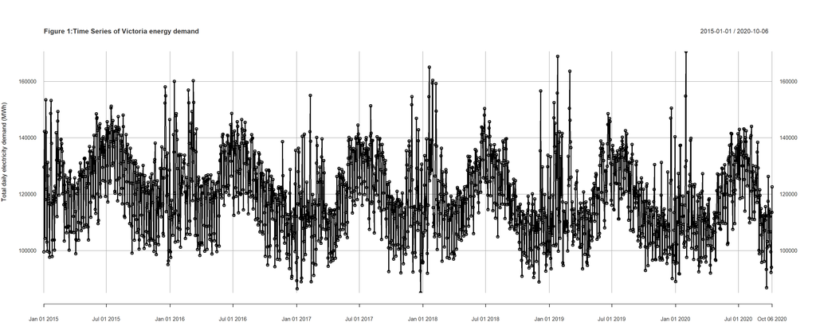

```r
#Plot the Time Series:
plot(Data_xts,type="o",ylab="Total daily electricity demand (MWh)",xlab="Year",
     main="Figure 1:Time Series of Victoria energy demand")
```

- **Trend**: A very slight downward trend.
- **Variance**: No obvious changing variance.
- **Seasonality**: It can be seen all the peaks occurring around July each year with short spikes occurring every January a This is as expected as generally more electricity is used during winter with the exception of very hot days during January aswell that is likely to cause large uptake in cooling systems.
- **Change Point**: No clear change point observed

As you can see in the plot above the time series data has relatively high granularity due to the fact daily data points are used. Because of this, this data is likely to contain multiple seasonal components on the day , week and month level. As the main objective of this report is to identify and forecast trends in the electricity demand on a monthly basis, this time series data will be aggregated on monthly basis.

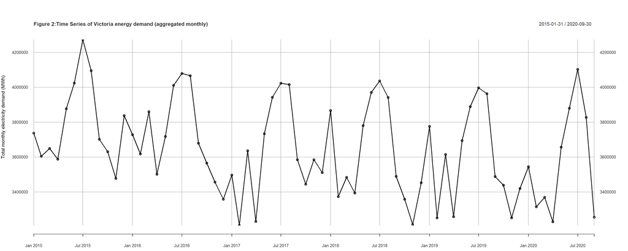

```r
# remove last 6 data points as they belong to separate month and will skew the summations
n<-dim(Data)[1]
df<-Data[1:(n-6),]
Data_xts <- xts(df$`demand`, df$date)

Data_xts_agg <- apply.monthly(Data_xts,sum)

#Plot the Time Series:
plot(Data_xts_agg,type="o",ylab="Total monthly electricity demand (MWh)",xlab="Year",
     main="Figure 2:Time Series of Victoria energy demand (aggregated monthly)")
```

Time series characteristics observed from the above plot:

- **Trend**: A very slight downward trend.
- **Variance**: No obvious changing variance.
- **Seasonality**: Needs to be further investigated, however annual repeating patterns can be seen around every January and july each year which strongly suggests the existence of seasonality.
- **Change Point**: No clear change point observed.

```r
# Summary Stats
summary(Data_xts_agg)
```

```
##      Index             Data_xts_agg
##  Min.   :2015-01-31   Min.   :3209217
##  1st Qu.:2016-06-30   1st Qu.:3453621
##  Median :2017-11-30   Median :3631206
##  Mean   :2017-11-29   Mean   :3654578
##  3rd Qu.:2019-04-30   3rd Qu.:3877235
##  Max.   :2020-09-30   Max.   :4273538
```

As seen in the summary data above, the data has a mean of 3654578 and a median of 3631206 , which is relatively similar indicating that the distribution is roughly symmetric if not slightly right-skewed. The min and max have a difference of 1064321 which is relatively large, indicating that there is significant variability in the data. The IQR of the data set is 423614 which indicates a moderate spread of data points around the mean. As both q1 and q3 are similar distance away from the median it can be concluded the data is relatively symmetric , however the slightly greater difference between q3 and the median does further indicate a slight positive skew.

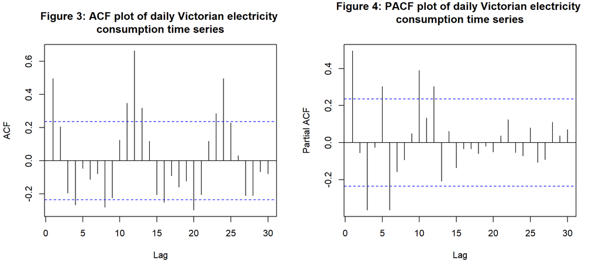

```r
# ACF and PACF
par(mfrow=c(1,2))
acf(Data_xts_agg,lag.max=30, main="Figure 3: ACF plot of daily Victorian electricity \nconsumption time series")
pacf(Data_xts_agg,lag.max=30, main="Figure 4: PACF plot of daily Victorian electricity \nconsumption time series")
```

From the ACF plot above we can see a very clear wave-like pattern which indicates the presence of seasonality in our data.The Pacf exhibits a slowly decreasing pattern which suggests a gradual decay of autocorrelation , suggesting the presence of a long-term/weak auto-regressive trend in the data. From this one can roughly deduce that a SARIMA model is likely going to be the best model-type for this data.

```r
# ADF test to test for stationarity
Stationary_tests(Data_xts_agg)
```

```
##
##  Augmented Dickey-Fuller Test
##
## data:  data
## Dickey-Fuller = -3.2417, Lag order = 4, p-value = 0.08841
## alternative hypothesis: stationary
##
##
##  Phillips-Perron Unit Root Test
##
## data:  data
## Dickey-Fuller Z(alpha) = -36.579, Truncation lag parameter = 3, p-value
## = 0.01
## alternative hypothesis: stationary
##
##
##  KPSS Test for Level Stationarity
##
## data:  data
## KPSS Level = 0.31195, Truncation lag parameter = 3, p-value = 0.1
```

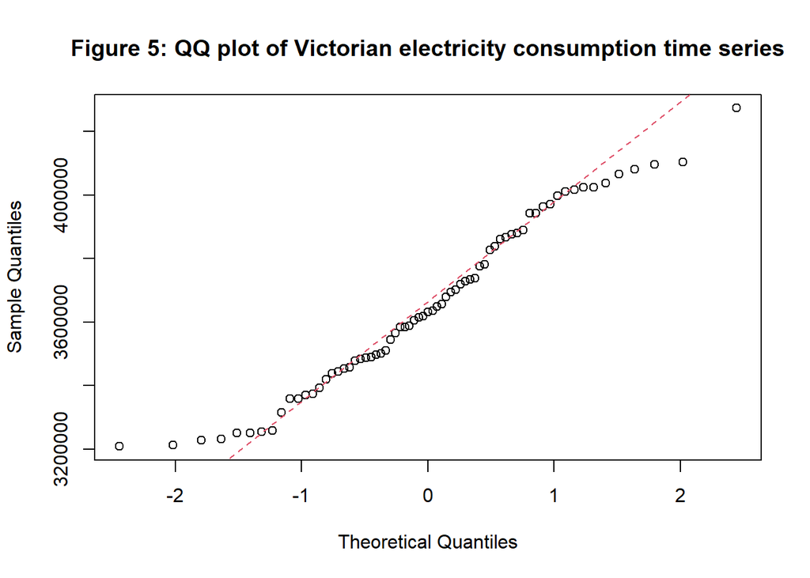

```
##
##  Shapiro-Wilk normality test
##
## data:  as.numeric(data)
## W = 0.96648, p-value = 0.06078
```

```r
# Check the degree of normality
Normalitytests(Data_xts_agg,"Figure 5: QQ plot of Victorian electricity consumption time series")
```

In order to test for normality in the data, Both a shaprio-wilk test and Q-Q plot was used. The shapiro-wilk test achieved a p-value of 0.06 and as this is greater than 0.05 we cannot reject the null hypothesis of normality. The Q-Q plot does show that the data follows the centre-line for the majority of points , however there still is deviation at the ends of the data meaning this data likely skirts on the edge of normality.

## 2.2 Impact of previous days

Another useful initial analysis to conduct is to determine whether or not previous years share a strong correlation or not.

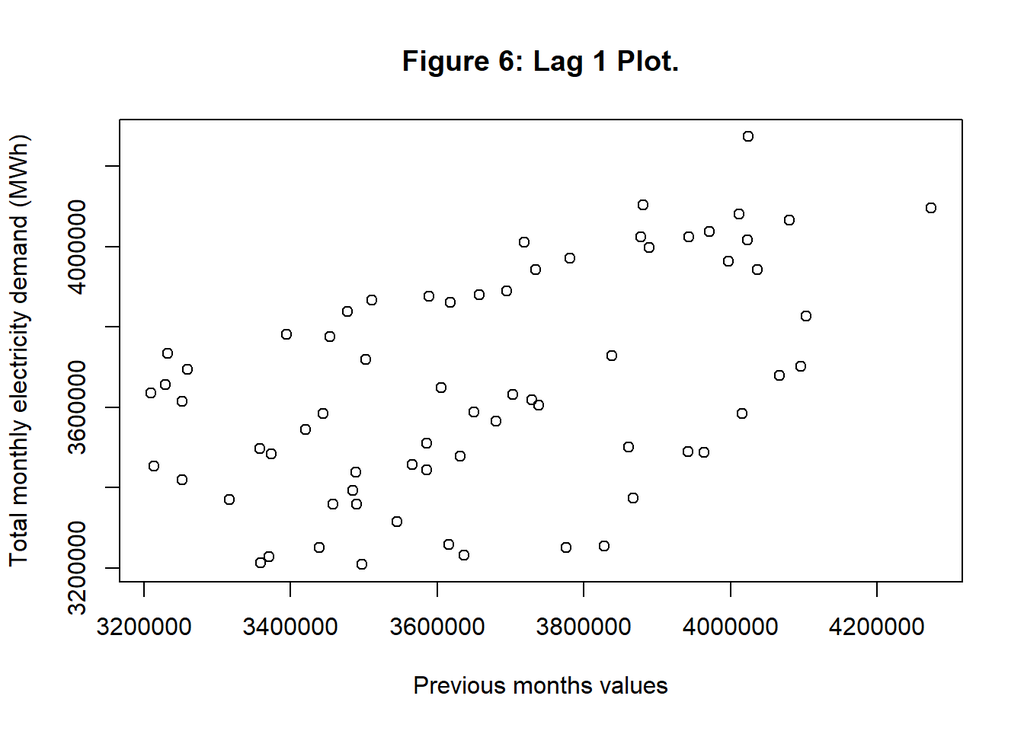

```r
# plot lag 1 scatterplot
plot(y=Data_xts_agg,x=zlag(Data_xts_agg),ylab="Total monthly electricity demand (MWh)", xlab='Previous months values', main = "Figure 6: Lag 1 Plot.")
```

```r
y = Data_xts_agg
x = zlag(Data_xts_agg)   # Generate first lag of the series
index = 2:length(x)  # Create an index to get rid of the first NA value in x
cor(y[index],x[index]) # Compute correlation coefficient of the data with its first lag
```

```
##           [,1]
## [1,] 0.5041434
```

The scatter plot above shows that there is a weak positive correlation between the energy demand on a given month and its succeeding months. the correlation coefficient of 0.50 shows that the correlation is relatively weak and confirms that the time series data exhibits some form of positive autocorrelation however not a significant amount and the data is NOT randomly distributed.

# 3. Identifying seasonality

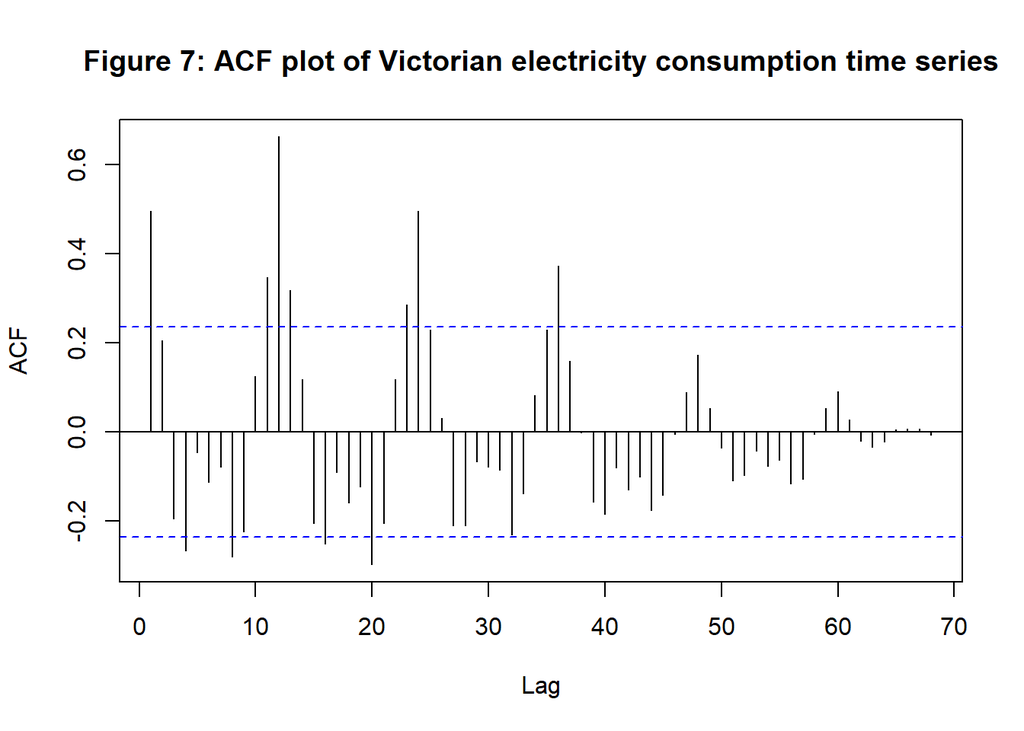

```r
#Plot acf plot of time series data
acf(Data_xts_agg, lag.max = 70,main="Figure 7: ACF plot of Victorian electricity consumption time series")
```

Because a wave pattern with clear significant lags was seen in the acf plot above and because the general time series plot shows clearly repeating patterns in July and January each year it and therefore non-stationary which will be further investigated.Using the ACF plot the amount of lags between each peak in the observed ossification pattern can be used to determine frequency.

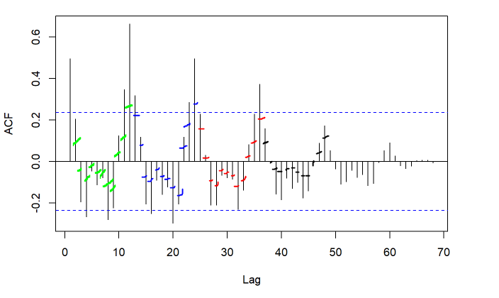

It can be seen that peaks occur at lags 1 , 12 , 24 etc. which suggest the seasonality of the series exhibits a frequency of approximately 12. This also is expected in terms of the context of the problem as energy usage is likely to go up every winter and start of summer. Because of this the frequency of 12 will be embdedded into the time series itself.

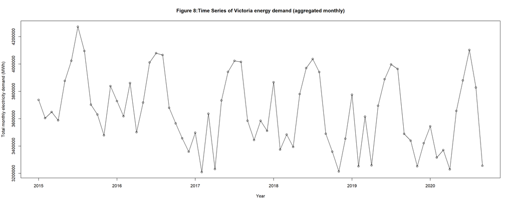

```r
# Convert to ts object so that we can add frequency:
Data <- df                                  # Duplicate data
Data$year <- strftime(Data$date, "%Y")    # Create year column
Data$month <- strftime(Data$date, "%m")   # Create month column

Data_agg <- aggregate(`demand` ~ month + year,       # Aggregate data
                        Data,
                        FUN = sum)
# Convert data into a time series object
Data_ts_agg = matrix(Data_agg$`demand`)
Data_ts_agg = as.vector(t(Data_ts_agg))


Data_ts_agg <- ts(Data_ts_agg,frequency=12,start =c(2015,1),end =c(2020,9) )
plot(Data_ts_agg,type="o",ylab="Total monthly electricity demand (MWh)",xlab="Year",
     main="Figure 8:Time Series of Victoria energy demand (aggregated monthly)")
```

# 4. Data transformations

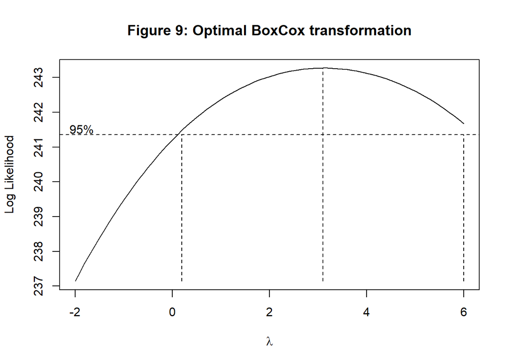

```r
# As the data is not normal a box cox transformation will be used to see if this improves normality
BC = BoxCox.ar(Data_ts_agg, lambda = seq(-2, 6, by = 0.1))
title(main = "Figure 9: Optimal BoxCox transformation")
```

```r
lambda <- BC$lambda[which(max(BC$loglike) == BC$loglike)]
lambda
```

```
## [1] 3.1
```

The optimal value of lambda in this instance is 3.1

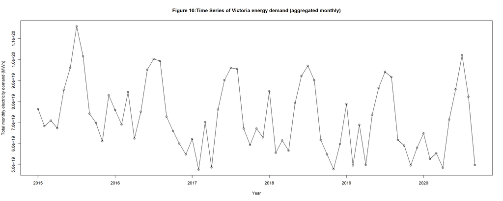

```r
# Apply box cox transformation to time series and see if normality has improved
Data_ts_agg_BC = (Data_ts_agg^lambda-1)/lambda
#Plot the Time Series:
plot(Data_ts_agg_BC,type="o",ylab="Total monthly electricity demand (MWh)",xlab="Year",
     main="Figure 10:Time Series of Victoria energy demand (aggregated monthly)")
```

```r
Stationary_tests(Data_ts_agg_BC)
```

```
##
##  Augmented Dickey-Fuller Test
##
## data:  data
## Dickey-Fuller = -3.3056, Lag order = 4, p-value = 0.07819
## alternative hypothesis: stationary
##
##
##  Phillips-Perron Unit Root Test
##
## data:  data
## Dickey-Fuller Z(alpha) = -34.509, Truncation lag parameter = 3, p-value
## = 0.01
## alternative hypothesis: stationary
##
##
##  KPSS Test for Level Stationarity
##
## data:  data
## KPSS Level = 0.28542, Truncation lag parameter = 3, p-value = 0.1
```

It can be seen in both the ADF and pp test above, the BoxCox transformation slightly increased the stationary of the time series.

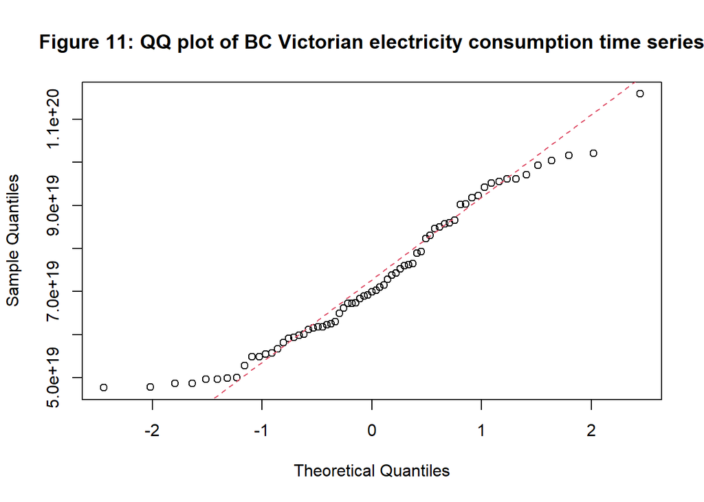

```
##
##  Shapiro-Wilk normality test
##
## data:  as.numeric(data)
## W = 0.95668, p-value = 0.01762
```

```r
# Check if normality has been improved
Normalitytests(Data_ts_agg_BC,"Figure 11: QQ plot of BC Victorian electricity consumption time series")
```

Based on the results of the Shapiro-Wilk test, it is observed that the Box-Cox transformation has made the time series less normal, as indicated by a p-value of 0.02. Consequently, since the transformation has had minimal impact on achieving stationarity and improving normality, it will not be utilized for the model.

Given that the model was not stationary, an initial first differencing will be employed. This differencing approach aims to remove any underlying trend present in the data and make it stationary, which is a crucial requirement for many time series models.

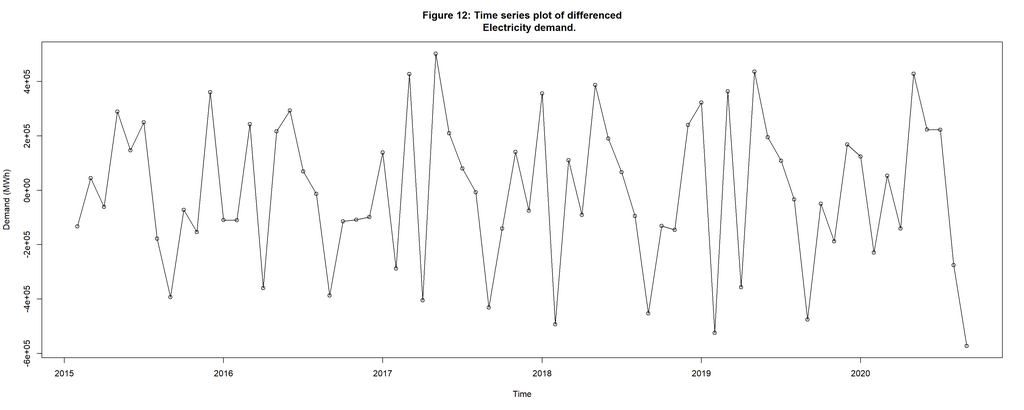

```r
# applying first differencing
diff.Data_ts_agg <- diff(Data_ts_agg)
par(mfrow=c(1,1))
plot(diff.Data_ts_agg,type='o',ylab = "Demand (MWh)", main='Figure 12: Time series plot of differenced
     Electricity demand.')
```

Upon initial inspection of the first differenced time series plot, it is observed that there are no apparent trends or changing variances. This suggests that the first differencing alone might be sufficient to make the time series stationary.

```r
# Use adf test on differenced series
Stationary_tests(diff.Data_ts_agg)
```

```
##
##  Augmented Dickey-Fuller Test
##
## data:  data
## Dickey-Fuller = -4.345, Lag order = 4, p-value = 0.01
## alternative hypothesis: stationary
##
##
##  Phillips-Perron Unit Root Test
##
## data:  data
## Dickey-Fuller Z(alpha) = -74.581, Truncation lag parameter = 3, p-value
## = 0.01
## alternative hypothesis: stationary
##
##
##  KPSS Test for Level Stationarity
##
## data:  data
## KPSS Level = 0.028624, Truncation lag parameter = 3, p-value = 0.1
```

Based on the results of the Augmented Dickey-Fuller (ADF) test, the p-value of 0.01 is less than the significance level of 0.05. Thus, the null hypothesis of non-stationarity can be rejected, and the differenced series can be considered stationary at a 95% confidence level.

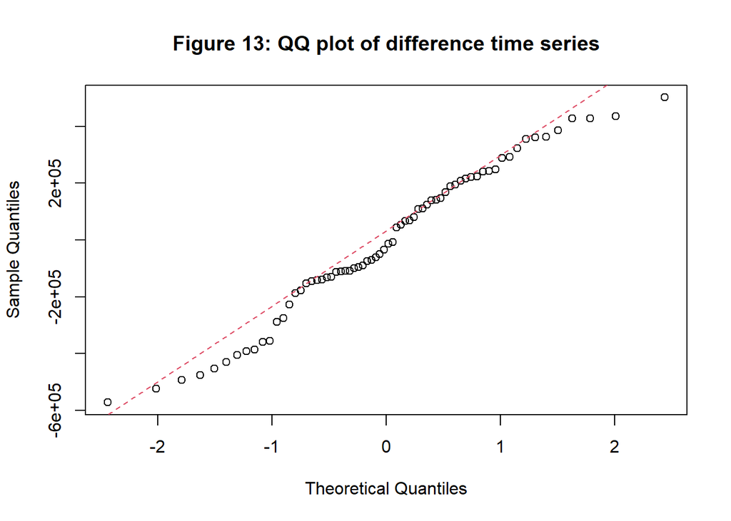

```
##
##  Shapiro-Wilk normality test
##
## data:  as.numeric(data)
## W = 0.97446, p-value = 0.1759
```

```r
# Test for normality of difference plot
Normalitytests(diff.Data_ts_agg,"Figure 13: QQ plot of difference time series")
```

The Shapiro-Wilk test resulted in a p-value greater than 0.05, indicating that, under the 95% confidence level, we can assume normality of the data. This is beneficial when fitting time series models because many models, such as SARIMA (Seasonal Autoregressive Integrated Moving Average), assume normality of the residuals.

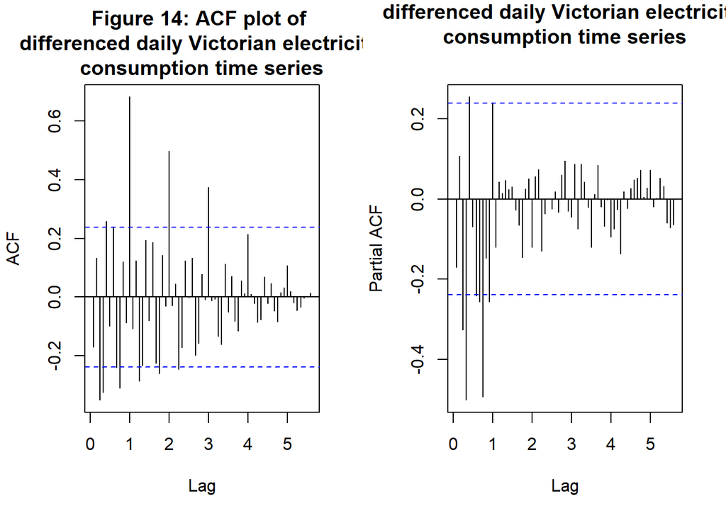

```r
# ACF and PACF to find period of differenced series
par(mfrow=c(1,2))
acf(diff.Data_ts_agg, lag.max = 70, main="Figure 14: ACF plot of \ndifferenced daily Victorian electricity \nconsumption time series")
pacf(diff.Data_ts_agg, lag.max = 70,main="Figure 15: PACF plot of \ndifferenced daily Victorian electricity \nconsumption time series")
```

from the acf and pacf plots above you can see that significant lags are still occurring at with slightly reduced wave-like pattern. The significant lags in the ACF plot indicate that past values of the time series are correlated with the current value, further indicating the presence of a seasonal pattern. Considering both the ACF and PACF, it becomes evident that the data still exhibits seasonality and trend components. These components need to be properly accounted for in subsequent modeling steps to ensure accurate forecasting and capturing the underlying patterns.

Therefore, it is crucial to incorporate appropriate seasonal and trend models, such as SARIMA (Seasonal Autoregressive Integrated Moving Average) or other techniques designed to handle time series data with seasonal and trend components.

# 5. Simple deterministic model (Linear + Seaonal model)

Before delving into more complex SARIMA models, we will start by fitting and analyzing a simpler deterministic model. The chosen model for this initial analysis is a hybrid additive model, which combines a seasonal model to capture yearly seasonality and a linear model to capture the decreasing trend.

```r
t <- time(Data_ts_agg)
month.=season(Data_ts_agg) # period added to improve table display and this line sets up indicators
Hybridmodel=lm(Data_ts_agg~month.+t-1) # -1 removes the intercept term
summary(Hybridmodel)
```

```
##
## Call:
## lm(formula = Data_ts_agg ~ month. + t - 1)
##
## Residuals:
##     Min      1Q  Median      3Q     Max
## -220520  -41803    3449   52567  218496
##
## Coefficients:
##                  Estimate Std. Error t value Pr(>|t|)
## month.January   108231300   14946905   7.241 1.38e-09 ***
## month.February  107939393   14947522   7.221 1.49e-09 ***
## month.March     108150783   14948139   7.235 1.41e-09 ***
## month.April     107919614   14948757   7.219 1.50e-09 ***
## month.May       108300373   14949374   7.244 1.36e-09 ***
## month.June      108514093   14949992   7.258 1.29e-09 ***
## month.July      108650996   14950609   7.267 1.25e-09 ***
## month.August    108554887   14951226   7.261 1.28e-09 ***
## month.September 108107398   14951844   7.230 1.44e-09 ***
## month.October   108040260   14948768   7.227 1.46e-09 ***
## month.November  107953793   14949386   7.221 1.49e-09 ***
## month.December  108077317   14950003   7.229 1.45e-09 ***
## t                  -51816       7409  -6.994 3.54e-09 ***
## ---
## Signif. codes:  0 '***' 0.001 '**' 0.01 '*' 0.05 '.' 0.1 ' ' 1
##
## Residual standard error: 101400 on 56 degrees of freedom
## Multiple R-squared:  0.9994, Adjusted R-squared:  0.9992
## F-statistic:  6921 on 13 and 56 DF,  p-value: < 2.2e-16
```

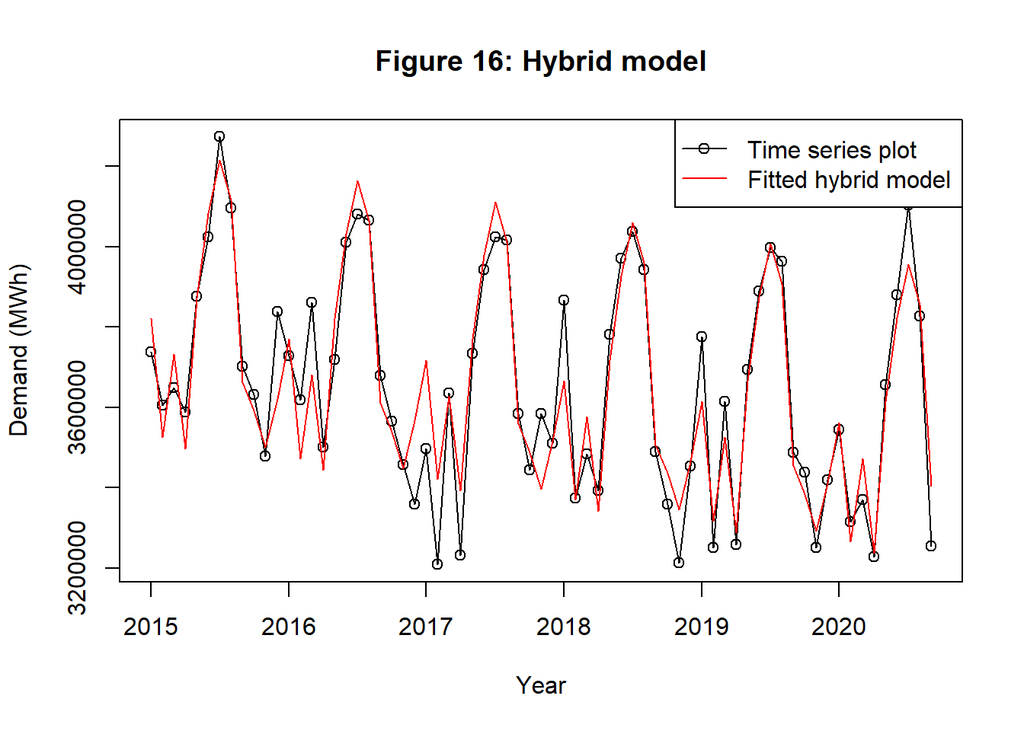

```r
plot(Data_ts_agg, main = "Figure 16: Hybrid model",ylab="Demand (MWh)",xlab='Year'
     ,type='o')
points(t,predict.lm(Hybridmodel),type='l',col='red') # superimpose the fit of model reg0 on the plot of the data
# Add legend
legend("topright", legend = c("Time series plot", "Fitted hybrid model"),
 col = c("black", "red"), lwd = 1, pch = c(1, NA))
```

```r
# Get standardized residuals
Hybridmodel.res=rstudent(Hybridmodel)


residual.analysis(Hybridmodel,'17')
```

```
##
##  Shapiro-Wilk normality test
##
## data:  res.model
## W = 0.97373, p-value = 0.1542
```

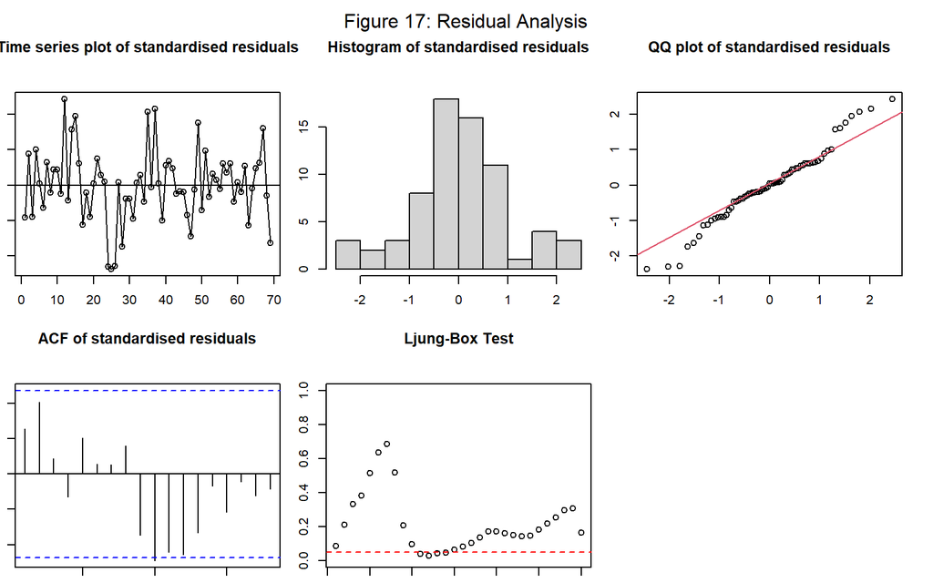

- **Histogram**: The histogram is relatively normal.  
- **QQ Plot**: The qqplot observed in this model at the tails of the data still significant deviates from the center line.  
- **ACF**: the lack of a wave-like pattern and significant lags shows that the models was able to significantly capture the seasonality and correlation present in the data.  
- **Shapiro-wilk test**: The shapiro-wilk normality test produced a p-value of 0.154. This value is greater than 0.05, meaning under a 95% confidence level and the null hypothesis is NOT rejected, meaning no significant departure from normality was found.

## 5.2 Forecast

```r
h <- 0.8333333333333334 # 10 months ahead forecasts
increment <- 12 # Frequency is 7
original.t <- t
n <- length(original.t) # Find the length of observation period
lastTimePoint <- original.t[n] # Find the last time point
ts <- seq(lastTimePoint ,
lastTimePoint +  h, 1/12)
new<- factor(rep(month.,1))[1:11] # Introducing the seasonal value for forecasting\\
daysahead <- data.frame(month. = new,t=ts)
pred <- predict.lm(Hybridmodel,daysahead,interval='prediction') # Computing the prediction as well as prediction interval
```

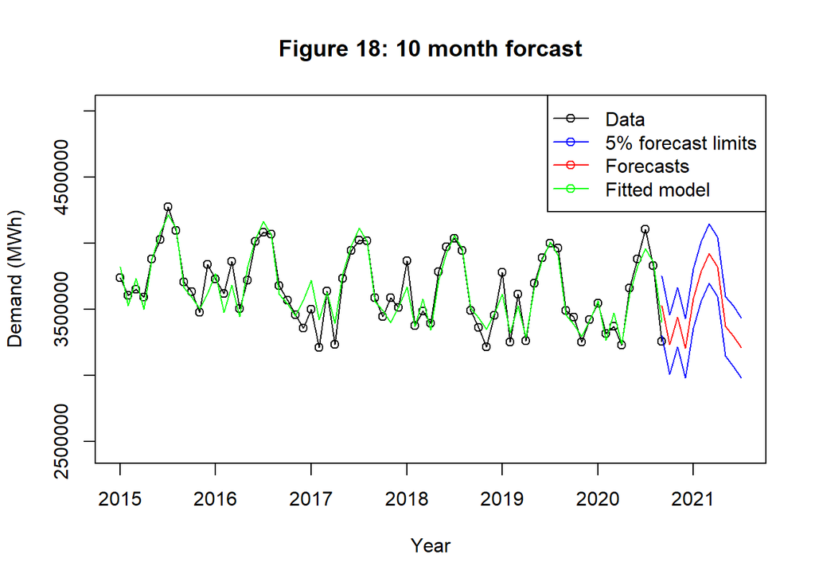

```r
# plot forcasted values
par(mfrow=c(1,1))
plot(Data_ts_agg, main = "Figure 18: 10 month forcast",ylab="Demand (MWh)",xlab='Year'
     ,type='o',ylim = c(min(c(fitted(Hybridmodel)-800000, as.vector(Data_ts_agg))),
              max(c(fitted(Hybridmodel)+800000, as.vector(Data_ts_agg)))),xlim=c(2015,2021.500))

points(t,predict.lm(Hybridmodel),type='l',col='green') # superimpose the fit of model reg0 on the plot of
lines(ts(as.vector(pred[,1]), start = c(2020.667,1),frequency = 12), col="red", type="l")
lines(ts(as.vector(pred[,2]), start = c(2020.667,1),frequency = 12), col="blue", type="l")
lines(ts(as.vector(pred[,3]), start = c(2020.667,1),frequency = 12), col="blue", type="l")
# Add legend
legend("topright", legend =  c("Data","5% forecast limits", "Forecasts","Fitted model"),
 col = c("black", "blue","red","green"), lwd = 1, pch = 1)
```

From the above plot we can see that the predictions do seem to follow the same very slow downward trend and the rough seasonal variations in the data. The red line represents the fitted values for the next 10months , while the blue lines indicate the upper and lower confidence intervals for the fitted values. For the simplicity of the model this is an adequate forecast , however its precision is effected by the stochastic nature of the seasonal trends as the difference in peaks between years does not seem to follow a specific trend.

# 6. SARIMA model

The more complex model that will be used to forecast this dataset will be a SARIMA model. This is because there is clear seasonality in the monthly aggregated time series with a period of 12 months. There is also constant variance with no clusters of high variance and therefore a GARCH model is not suitable for this time series. This model is therefore more likely to pick up on the slight year deviations in values.To begin finding possible PDQ and pdq parameters for the SARIMA model, first the seasonal component must be modeled by finding the P and Q values. The residuals analysis approach was used to find possible seasonal P and Q values.